# RP02

聖心女子大学国際交流学科  
2024年秋学期

アジア経済研究所 伊藤成朗

これも価格が安すぎる例です(先週末の銀座三越)

[figure not shown]

AIに殺人を判断させるのは戦争がより身近になってしまうように思いました。技術発展するにつれて、暴力性が高まっていってしまうという事実を考えさせられました

人間を介さないAIによる殺人はすでに行われています。[2023年のForbesの記事](https://www.forbes.com/sites/davidhambling/2023/10/17/ukraines-ai-drones-seek-and-attack-russian-forces-without-human-oversight/)によると、ウクライナがドローン攻撃でAIに標的を判断させているそうです。

- 妨害電波によって無線が使えない場合、自律的な攻撃判断なしにドローン攻撃はできません。
- ドローンが標的を判断するようすを映したSaker社の[ビデオ](https://youtu.be/tLUmv9TO9xU)

> The Aim is to enable an extremely fast reconnaissance-decision making-strike process (also known as the ‘kill chain’) in a way that is not possible when humans are involved.
- 自律的ドローンが標的を探知し攻撃する[ビデオ](https://youtu.be/M7tmYBmI0kM)
  - 注意: この映像だけだと真偽は分かりませんので、映像はfakeの可能性もあります…

> The spokesman noted that the AI is not perfect, but their priority was getting a useful system that saves lives into the field. As mentioned, Saker are in constant contact with users and the system is updated continuously.

怖いコメントです。

貧困の罠についての内容が興味深かったです。所得が低い時には、資産の蓄積度合いは緩s、所得が一定のポイントを超えると資産の蓄積が高くなるS字方のグラフを見ました。その原因について、資本市場・保険市場・貸出市場・市場に関わる制度の４つの観点が挙げられていました。その中でも、資本市場・保険市場・貸出市場の３点については、繋がりがあるように感じました。子供への投資・より収益の高い作物の育成と収穫を行うためには、資金が必要です。しかし、金融機関は資金を回収できないリスクを考えて、低所得の家庭には、資金を貸しにくいです。初期資本がないことが、短期間で貧困から回復することが難しい原因になっていると感じました。

良い観点だと思います。なぜならば、「低開発」はさまざまな市場や制度が未発達な状態だからです。複数の原因が複合的に投資の収益を低くしているはずです。

- この場合、一つの原因だけに対処するだけで投資が進むのか分かりません。
- RCTが示す単一の課題・原因に対する対処法で十分なのかは分かりません。
  - でも、単一の課題・原因にすら対処法を示せてこなかったRCT以前があります。

貧困の罠という単語はキリスト教学やラテンアメリカ地域論のCCTプログラムなどで聞いたことのありましたが、貧困の罠という単語については言葉で説明され、自分で想像するといった理解の仕方であったので、今回の講義で図を用いて検討したことで、自分の想像だけでなく理論的に理解が出来たように感じました。

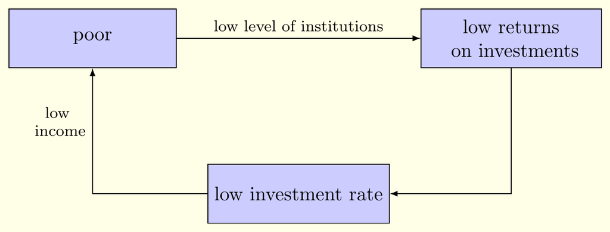

- こんな感じの図を見たことがあるかもしれません。「貧困の悪循環」。ほぼ恒等的(トートロジカル)な図なので、解決策を提示できていません。

講義で用いた図の強み: 時間を通じた資本の変化を示して

- 初期時点の資本量が一定以下であれば低い均衡、それ以上だと高い均衡に分かれること
- よって、ビッグプッシュという解決策を提示していること

Galor and Zeira (1993) の図(理論モデル)が$L$→$H$の解決策を提示できるのは、貧困の悪循環に陥る均衡$L$と抜け出したときの均衡$H$を同時に示しているから

- S字線の位置(収益率水準)や傾き(収益率の増え方=限界収益率)によって行き着く均衡が変わる
- 位置や傾きを変える政策を議論できる

日本では、そもそも前科がある人の雇用に関して大きな関心が持たれていない印象が強く、日本とアメリカの異文化が背景にあるのだろうと考えます。この点については、日本での雇用環境との違いを再認識する機会になりました。アメリカでの職業差別に対する政策が抱えるジレンマに触れることで、日本の雇用慣行に関する考え方も一度見直す必要があるのではないかとも思いました。

断片的な情報しか知りませんが、日本でも犯罪歴のある人が再就職して生計を立てることは困難です

アメリカとの差は、

- 銃やドラッグがアメリカほど蔓延しておらず、犯罪発生率が低いこと
- 人種の違いが少ないので、人種差別の件数が少なく顕在化していないこと

国際比較可能なデータを見つけたので、次ページで殺人犠牲者数比率(10万人あたり)を比較しました

年ごとの標本サイズを調べます

```
1990 1991 1992 1993 1994 1995 1996 1997 1998 1999 2000 2001 2002 2003 2004 2005
  94   90   95   94  102  104  103  106  105  110  122  132  133  116  134  129
2006 2007 2008 2009 2010 2011 2012 2013 2014 2015 2016 2017 2018 2019 2020 2021
 137  150  160  159  157  149  152  130  128  130  129  129  129  136  130  115
2022 2023
  99   12
```

最近年で標本サイズが大きい2020年を選んで描画

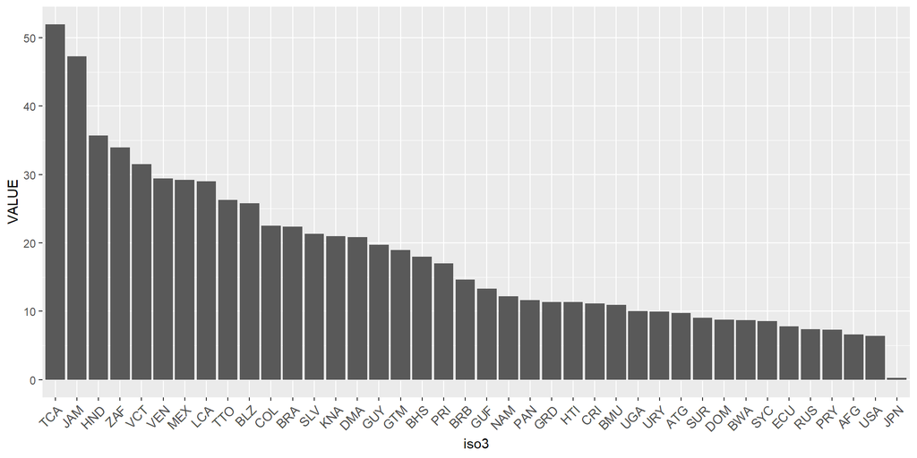

出所: https://dataunodc.un.org/dp-intentional-homicide-victims

- 日本よりも相当多い(20倍以上)

データを読んで整形するRのコード

````markdown
```{r read UN homicide data}
grepout <- function(str, x)
  # returns element of match (not numbers)
  x[grep(str, x, perl = T)]
#### setwd(path <- "c:/seiro/docs/external/seishin/lec_slides/2024/RP/")
library(data.table)
hd <- fread("HomicideData.tsv", skip = 2, header = T)
#### Change column name: Unit of measurement => Units
#### Change column name: Iso3_code => iso3
setnames(hd, c(grepout("Uni", colnames(hd)), "Iso3_code"), c("Units", "iso3"))
#### Character columns => factor columns
chacol <- colnames(hd)[grepl("cha", sapply(hd, class))]
hd[, (chacol) := lapply(.SD, factor), .SDcol = chacol]
#### Choose data:
####   Total for Sex, Age, Dimension, Category
####   Units = Rates per 10000, Indicator != Regional estimates
####   iso3 must be 3 characters long (>3 is a region of a country)
hdt <- hd[grepl("T", Sex) & grepl("T", Age) & grepl("T", Dimension) &
  grepl("T", Category) & grepl("Rate", Units) & !grepl("Reg", Indicator) &
  nchar(as.character(iso3)) == 3, ]
summary(hdt)
#### Drop unused levels in factors
hdt[, (chacol) := lapply(.SD, droplevels), .SDcol = chacol]
summary(hdt)
#### Use only number of victims
hdt <- hdt[grepl("Vic", Indicator), ]
hdt[, (chacol) := lapply(.SD, droplevels), .SDcol = chacol]
```
````

年ごとの標本サイズ

````markdown
```{r}
table(hdt[, Year])
```
````

描画

````markdown
```{r plot UN homicide in 2020, width = 800}
#### Tabulate num of observations by year:
####   2020 is most recent among large number of obs
setkey(hdt, Year, VALUE)
setorder(hdt, Year, -VALUE)
library(ggplot2)
hdt2 <- hdt[grepl("2020", Year), .(iso3, VALUE)]
hdt2[, iso3 := factor(iso3, levels =
reorder(iso3, -VALUE)
)]
ggplot(data = hdt2[c(1:39, grep("JPN", iso3)), ],
    aes(x = iso3, y = VALUE)) +
  geom_col() +
  theme(
    axis.text.x = element_text(size = 10, angle = 45, hjust = 1, vjust = 1)
  )
```
````

日本の財務基盤が安定した時日本の子供は平等に学べるのでしょうか。

簡潔で良い質問だと思いました

まず、日本は公教育に関しては中学校までとても平等だと思います

- 高校以前段階の問題は公教育の質です
- 学級崩壊や教員多忙などで公立小学校・中学校での学習の質は低下
  - [2019年度](https://www.mext.go.jp/content/20230524-mext-tokubetu01-000026255_01.pdf#page=7): 小中学生男子で「学習面又は行動面で著しい困難を示す」割合=12.1%
  - うち、特別な教育支援が必要と判断されている割合: 28.7%
    - 小中学校著しい困難ありで放置: 男子8.63%、女子3.85%→1.51, 0.67人/35人学級
  - 僕の知る限り、地方や国の政治家はほとんど取り上げません
  - 集票に効果がないと考えているのかもしれません(想像)
  - PISA(15歳)などで学力低下が表面化していないことも原因でしょう
    - [数学的リテラシー(1位/5位)、読解力(2位/3位)、科学的リテラシー(1位/2位)](https://www.nier.go.jp/kokusai/pisa/pdf/2022/01_point_2.pdf#page=2)
- 高校以前段階で私立学校教育の質がより高いならば、所得と学習の正相関が出てきます

日本の財務基盤が安定した時日本の子供は平等に学べるのでしょうか。

高等学校等就学支援金制度(2020年度-): 高校は家庭年収660万円以下(1030万円)であれば約40万円(約12万円)を上限に授業料が減額されます

- 東京都などは年収制限無しに無償化しています

- 大学進学希望者どれだけの割合になるのかよく分かりませんが、あまり多くないでしょう
- 聖心女子大学: 入学金25万、授業料70万、施設設備費30万、諸費10万
- 慶應義塾大学経済学部: 入学金20万、授業料92万、その他29万

日本政府は対象者を拡げ、教育にもっと支出しても良いのではと思います

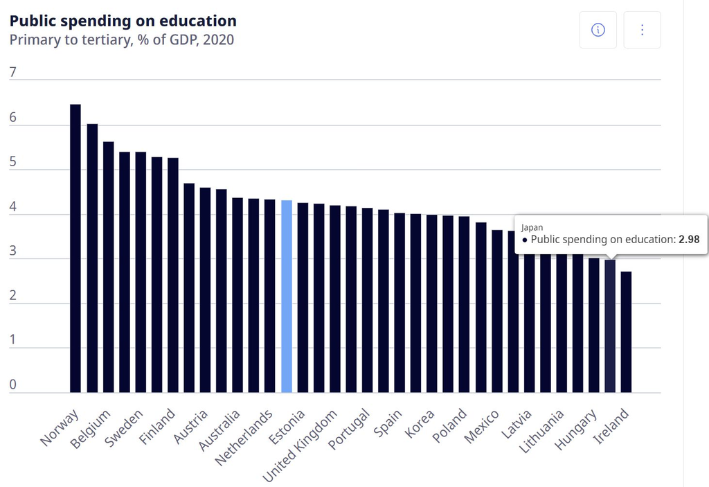

出所: https://www.oecd.org/en/data/indicators/public-spending-on-education.html

令和6年度の文教予算は4兆624億

- 高等教育の修学支援新制度(5438億円)は社会保障関係費(消費税財源)に計上されている
  - 2020年度(令和2年度)は4882億
- OECDの数値に入っていないものと仮定すると2.98%→3.34%
- [高齢予算対GDP比(2020年度)](https://www.ipss.go.jp/ss-cost/j/fsss-R02/R02-houdougaiyou.pdf#page=5): 9.11%
- [20歳以下人口](https://www.e-stat.go.jp/dbview?sid=0003459019)2088.4万人(16.58%)、60歳以上4349.6万人(34.54%)←60歳から受給可能
- 1000人あたり支出: 文教0.000160%、高齢0.000209%、高齢予算が1人あたり31%多い
- 保健(介護保険、医療保険など)は含めず
- 含めたら、世代間公的支出格差はもっと増えます
- 日本の大学授業料は安いので、政府が補助しても世代間公的支出格差は埋まらないと思います

[figure not shown]

http://seiroito.github.io/SHLectures/lec_slides/2024/RP/RP02.html

Galor, Oded, and Joseph Zeira. 1993. “Income Distribution and Macroeconomics.” *The Review of Economic Studies* 60 (1): 35–52. https://doi.org/10.2307/2297811.